# **🧩 Phase – 1: Data Understanding**

In this phase, we start by **exploring and understanding the dataset** before doing any cleaning or analysis.  
The main goal is to know what kind of data we have, how many records and columns are present, and what each column means.

## **📊 What We Check in This Phase**

- 🧮 **Number of rows and columns** in the dataset
- 🏷️ **Column names** and their **data types**
- ⚙️ **Basic structure** and a look at the **first few rows**
- 🔍 Checking for **missing**, **duplicate**, or **strange values**

## **📘 Understanding the Dataset**

Each **row** in this dataset represents a **unique customer record**, capturing personal, financial, and demographic details.

### **🧾 Key Features**

- **Age:** Customer’s age in years
- **Experience:** Number of years of professional experience
- **Income:** Annual income (in thousand dollars)
- **ZIP Code:** Customer’s location identifier
- **Family:** Family size (number of members)
- **CCAvg:** Average monthly credit card spending
- **Education:** Education level (1 = Undergrad, 2 = Graduate, 3 = Advanced/Professional)
- **Mortgage:** Value of house mortgage (if any)
- **Personal Loan:** Whether the customer accepted a loan (`1` = Yes, `0` = No)

### **🎯 Target Variable**

- **Personal Loan** — The main outcome variable that indicates whether a customer **accepted the loan offer**.

### **📊 Data Quality Summary**

- **Total Records:** ~5000
- **Total Columns:** 14
- **Missing Values:** None
- **Duplicate Values:** None
- **Data Type:** Mostly numeric (ideal for modeling)

## **💡 Why This Matters**

Understanding this data is essential because it helps banks and analysts:

- 🎯 **Improve targeted marketing** by identifying customers likely to accept loans
- 📈 **Increase conversion rates** through better customer segmentation
- ⚙️ **Optimize resources** for high-potential customers
- 🧠 **Manage risk** by analyzing customer behavior and decision patterns

# **📂 Data Loading and Initial Exploration**

## **🧩 Importing Libraries and Loading the Dataset**

To begin the project, we first import the necessary Python libraries and load our dataset.

```python
import pandas as pd
import matplotlib.pyplot as plt
import seaborn as sns
```

```python
df = pd.read_csv(r"C:\Users\Hope\Downloads\Bank_Personal_Loan_Modelling.csv")
```

```python
df.shape
```

```
(5000, 14)
```

```python
df.head()
```

|  | ID | Age | Experience | Income | ZIP Code | Family | CCAvg | Education | Mortgage | Personal Loan | Securities Account | CD Account | Online | CreditCard |
| --- | --- | --- | --- | --- | --- | --- | --- | --- | --- | --- | --- | --- | --- | --- |
| 0 | 1 | 25 | 1 | 49 | 91107 | 4 | 1.6 | 1 | 0 | 0 | 1 | 0 | 0 | 0 |
| 1 | 2 | 45 | 19 | 34 | 90089 | 3 | 1.5 | 1 | 0 | 0 | 1 | 0 | 0 | 0 |
| 2 | 3 | 39 | 15 | 11 | 94720 | 1 | 1.0 | 1 | 0 | 0 | 0 | 0 | 0 | 0 |
| 3 | 4 | 35 | 9 | 100 | 94112 | 1 | 2.7 | 2 | 0 | 0 | 0 | 0 | 0 | 0 |
| 4 | 5 | 35 | 8 | 45 | 91330 | 4 | 1.0 | 2 | 0 | 0 | 0 | 0 | 0 | 1 |

```python
df.tail()
```

|  | ID | Age | Experience | Income | ZIP Code | Family | CCAvg | Education | Mortgage | Personal Loan | Securities Account | CD Account | Online | CreditCard |
| --- | --- | --- | --- | --- | --- | --- | --- | --- | --- | --- | --- | --- | --- | --- |
| 4995 | 4996 | 29 | 3 | 40 | 92697 | 1 | 1.9 | 3 | 0 | 0 | 0 | 0 | 1 | 0 |
| 4996 | 4997 | 30 | 4 | 15 | 92037 | 4 | 0.4 | 1 | 85 | 0 | 0 | 0 | 1 | 0 |
| 4997 | 4998 | 63 | 39 | 24 | 93023 | 2 | 0.3 | 3 | 0 | 0 | 0 | 0 | 0 | 0 |
| 4998 | 4999 | 65 | 40 | 49 | 90034 | 3 | 0.5 | 2 | 0 | 0 | 0 | 0 | 1 | 0 |
| 4999 | 5000 | 28 | 4 | 83 | 92612 | 3 | 0.8 | 1 | 0 | 0 | 0 | 0 | 1 | 1 |

## **🧮 Key Observations**

- The dataset contains **5000 rows** and **14 columns**, meaning it holds information about **5000 customers** and **14 related features**.
- The first few rows (`df.head()`) and last few rows (`df.tail()`) display the **structure and layout** of the data.
- Columns include details such as:  
  `Age`, `Experience`, `Income`, `ZIP Code`, `Family`, `CCAvg` *(Average Credit Card Spending)*, `Education`, `Mortgage`, and other **bank account-related attributes**.
- The **target variable** is `Personal Loan`, which indicates whether a customer **accepted the loan offer** (`1 = Yes`, `0 = No`).

## **💡 Conclusion**

The dataset appears **clean and well-structured**, with **no missing values** visible at first glance.  
It provides a **solid foundation** to move into the **Data Cleaning Phase**, where we’ll check for:

- Correct data types
- Outliers and inconsistencies
- Overall data quality before analysis

# **🧹 Checking for Missing and Duplicate Values**

Before cleaning the data, it’s important to check if there are any missing or duplicate records.  
Missing values can lead to wrong analysis results, and duplicate rows can create data imbalance.

```python
df.isnull().sum()
```

```
ID                    0
Age                   0
Experience            0
Income                0
ZIP Code              0
Family                0
CCAvg                 0
Education             0
Mortgage              0
Personal Loan         0
Securities Account    0
CD Account            0
Online                0
CreditCard            0
dtype: int64
```

```python
df.duplicated().sum()
```

```
0
```

## **🔍 Observations**

- All columns have 0 missing values, which means every record is complete.
- The dataset also has 0 duplicate rows, meaning there are no repeated entries.

## **✅ Conclusion**

The dataset is already well-structured and doesn’t require any missing value or duplication handling.  
This makes it ready for deeper cleaning steps like checking data types, inconsistencies, or outliers in the next phase.

# **🧾 Dataset Information Overview**

To understand the dataset better, the `df.info()` function was used.  
It provides details such as the total number of entries, data types of each column, and whether any missing values exist.

```python
df.info()
```

```
<class 'pandas.core.frame.DataFrame'>
RangeIndex: 5000 entries, 0 to 4999
Data columns (total 14 columns):
 #   Column              Non-Null Count  Dtype
---  ------              --------------  -----
 0   ID                  5000 non-null   int64
 1   Age                 5000 non-null   int64
 2   Experience          5000 non-null   int64
 3   Income              5000 non-null   int64
 4   ZIP Code            5000 non-null   int64
 5   Family              5000 non-null   int64
 6   CCAvg               5000 non-null   float64
 7   Education           5000 non-null   int64
 8   Mortgage            5000 non-null   int64
 9   Personal Loan       5000 non-null   int64
 10  Securities Account  5000 non-null   int64
 11  CD Account          5000 non-null   int64
 12  Online              5000 non-null   int64
 13  CreditCard          5000 non-null   int64
dtypes: float64(1), int64(13)
memory usage: 547.0 KB
```

## **🧮 Key Details Observed**

- The dataset contains **5000 records** and **14 columns**.
- Each column has **5000 non-null values**, confirming there are **no missing entries**.
- There are **13 integer columns (`int64`)** and **1 float column (`float64`)**, which is **CCAvg** (Average Credit Card Spending).
- The dataset’s **memory usage** is around **547 KB**, making it lightweight and easy to process.

## **💡 Conclusion**

All columns contain **valid data with correct data types**.  
Since most features are numeric, this dataset is **well-suited for analysis and model building**.  
As there are **no missing or object-type columns**, the next phase will focus on **data consistency checks and outlier detection**.

# **📊 Statistical Summary of the Dataset**

To understand the range and distribution of the data, the `df.describe()` function was used.  
It provides key statistical details such as **mean**, **minimum**, **maximum**, and **quartile** values for each numeric column.

```python
df.describe().T
```

|  | count | mean | std | min | 25% | 50% | 75% | max |
| --- | --- | --- | --- | --- | --- | --- | --- | --- |
| ID | 5000.0 | 2500.500000 | 1443.520003 | 1.0 | 1250.75 | 2500.5 | 3750.25 | 5000.0 |
| Age | 5000.0 | 45.338400 | 11.463166 | 23.0 | 35.00 | 45.0 | 55.00 | 67.0 |
| Experience | 5000.0 | 20.104600 | 11.467954 | -3.0 | 10.00 | 20.0 | 30.00 | 43.0 |
| Income | 5000.0 | 73.774200 | 46.033729 | 8.0 | 39.00 | 64.0 | 98.00 | 224.0 |
| ZIP Code | 5000.0 | 93152.503000 | 2121.852197 | 9307.0 | 91911.00 | 93437.0 | 94608.00 | 96651.0 |
| Family | 5000.0 | 2.396400 | 1.147663 | 1.0 | 1.00 | 2.0 | 3.00 | 4.0 |
| CCAvg | 5000.0 | 1.937938 | 1.747659 | 0.0 | 0.70 | 1.5 | 2.50 | 10.0 |
| Education | 5000.0 | 1.881000 | 0.839869 | 1.0 | 1.00 | 2.0 | 3.00 | 3.0 |
| Mortgage | 5000.0 | 56.498800 | 101.713802 | 0.0 | 0.00 | 0.0 | 101.00 | 635.0 |
| Personal Loan | 5000.0 | 0.096000 | 0.294621 | 0.0 | 0.00 | 0.0 | 0.00 | 1.0 |
| Securities Account | 5000.0 | 0.104400 | 0.305809 | 0.0 | 0.00 | 0.0 | 0.00 | 1.0 |
| CD Account | 5000.0 | 0.060400 | 0.238250 | 0.0 | 0.00 | 0.0 | 0.00 | 1.0 |
| Online | 5000.0 | 0.596800 | 0.490589 | 0.0 | 0.00 | 1.0 | 1.00 | 1.0 |
| CreditCard | 5000.0 | 0.294000 | 0.455637 | 0.0 | 0.00 | 0.0 | 1.00 | 1.0 |

## **🧮 Key Observations**

- The dataset has **5000 valid records** for every column.
- The **average age** of customers is around **45 years**, with most people between **35 and 55 years old**.
- The **average income** is about **73K**, while the **maximum income** reaches **224K**, showing a wide income range.
- The **average experience** is **20 years**, but some **negative values (e.g., –3)** indicate minor data errors that need correction.
- The **average credit card spending (CCAvg)** is around **1.9**, and **family size** mostly ranges between **1 to 4 members**.
- The **mortgage value** shows high variation, ranging from **0 to 635**.
- The **Personal Loan** column has a **mean of 0.096**, meaning only **9.6% of customers** accepted the loan offer.

## **💡 Conclusion**

The dataset is **mostly balanced and consistent**, but a few columns like **Experience** and **Mortgage** may need **further inspection** for outliers or inconsistencies in the upcoming **data cleaning phase**.

# **📊 Distribution & Outlier Visualization (Histogram + Boxplot)**

In this step, I visualized each **numeric column** using both a **Histogram** (to understand data distribution) and a **Boxplot** (to detect outliers).  
This helps in identifying **skewness**, **imbalance**, and **extreme values** present in the dataset.

```python
imp_cols = ['Age', 'Experience', 'Income', 'Family', 'CCAvg',
       'Education', 'Mortgage', 'Personal Loan', 'Securities Account',
       'CD Account', 'Online', 'CreditCard']
```

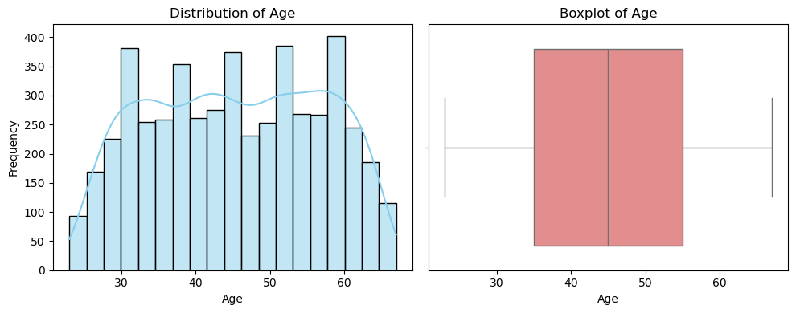

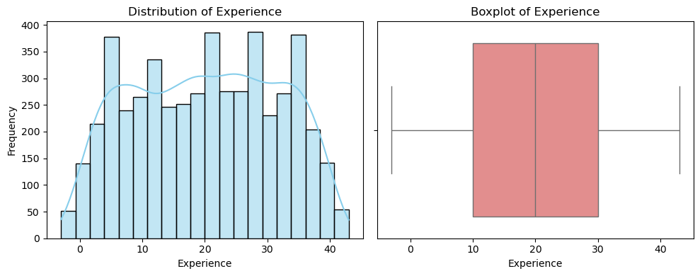

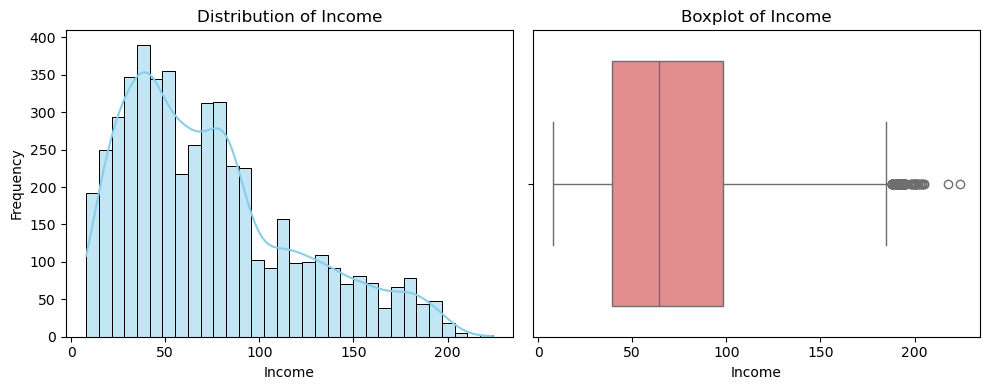

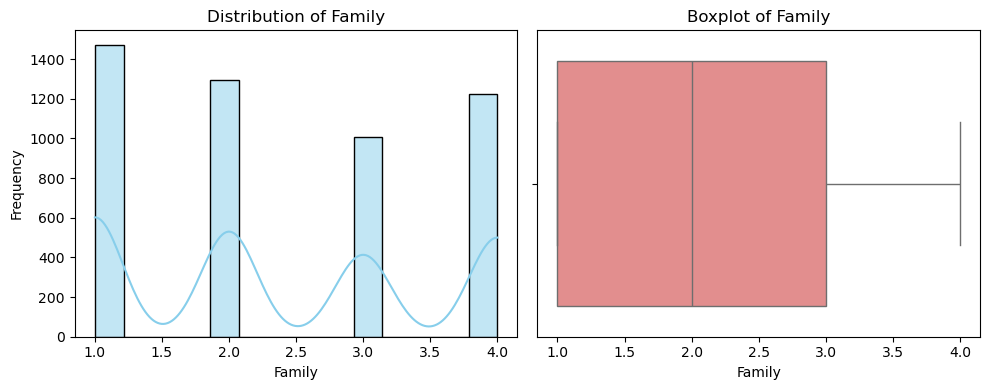

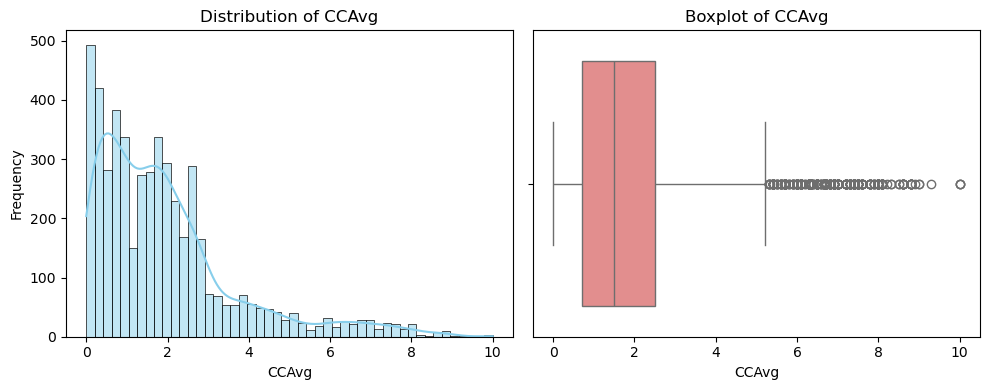

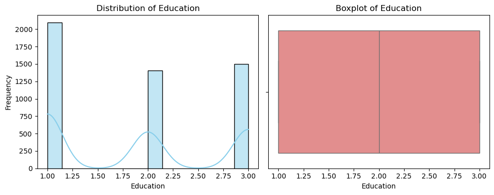

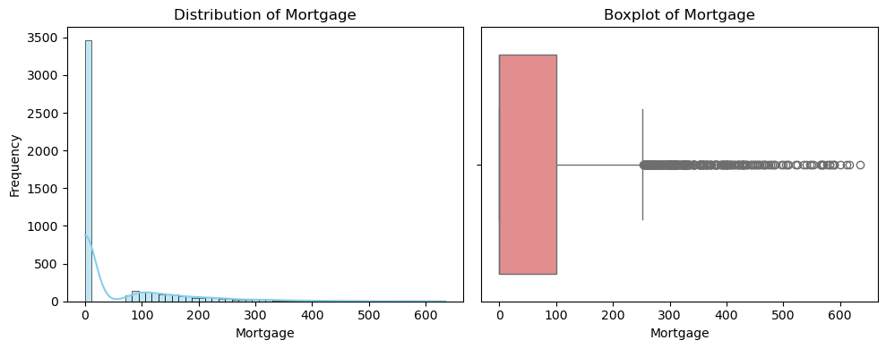

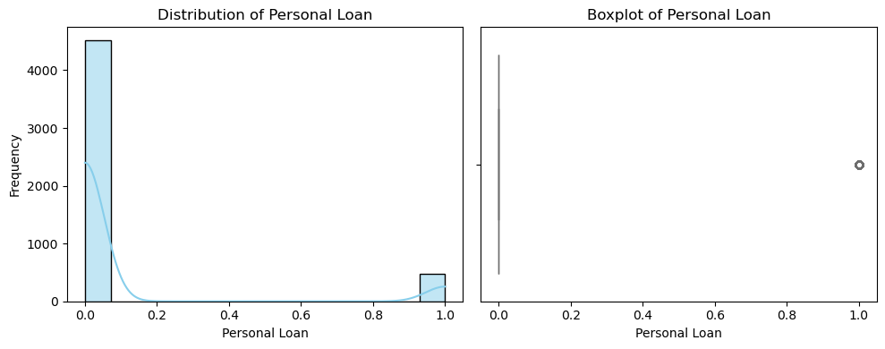

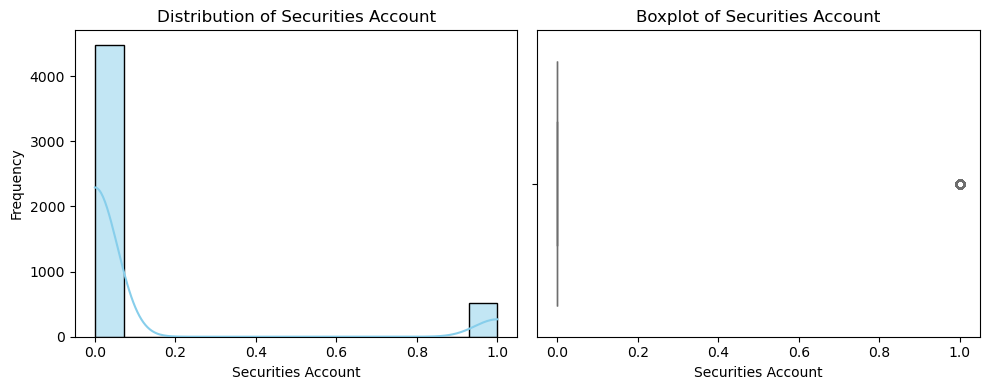

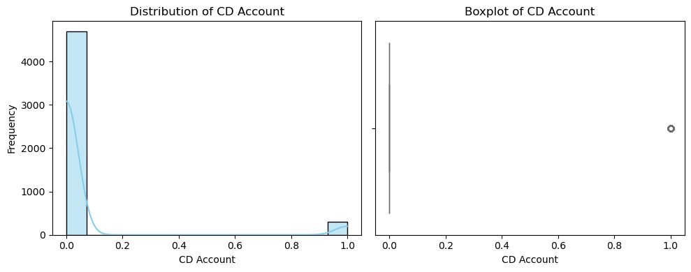

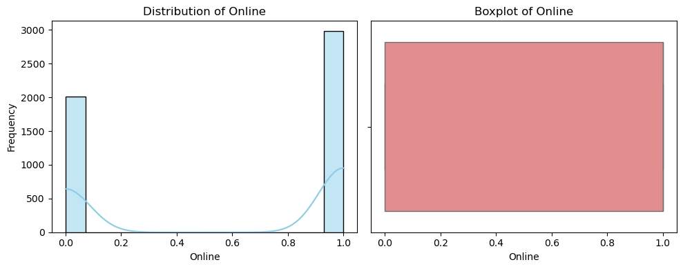

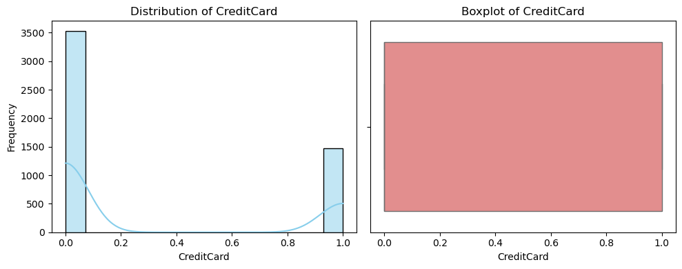

```python
for i in imp_cols:
    plt.figure(figsize=(10, 4))

    # Left: Histogram
    plt.subplot(1, 2, 1)
    sns.histplot(df[i], kde=True, color='skyblue')
    plt.title(f'Distribution of {i}')
    plt.xlabel(i)
    plt.ylabel('Frequency')

    # Right: Boxplot
    plt.subplot(1, 2, 2)
    sns.boxplot(x=df[i], color='lightcoral')
    plt.title(f'Boxplot of {i}')
    plt.xlabel(i)

    plt.tight_layout()
    plt.show()
```

## **💡 Conclusion**

Visualizing all numeric features side-by-side provides a **clear overview** of data patterns and outliers.  
It highlights:

- **Negative “Experience” values** that require correction.
- **Highly skewed features** like **Income** and **Mortgage** that may need transformation or capping.

This step sets the stage for the **data cleaning and correction phase**, ensuring a more accurate and reliable dataset for further analysis. 🚀

# **🧩 Phase – 1: Data Understanding – Summary**

In this phase, I explored and understood the **Bank Personal Loan Modelling** dataset to get a clear idea of its **structure, features, and data quality** before performing any cleaning or modeling.  
This dataset, available on **Kaggle**, contains information about **5000 bank customers** and their likelihood of accepting a **personal loan offer**.

## **🏦 About the Dataset**

The main goal of this dataset is to help a bank **predict which existing customers are more likely to accept a personal loan offer**.  
It includes **personal, demographic, and financial details** such as income, age, family size, education, average credit-card spending, and account status.

## **🧾 Basic Structure**

- **Total Records:** 5000
- **Total Columns:** 14
- **Data Types:** 13 integer (`int64`) and 1 float (`float64`)
- **Missing Values:** 0 ✅
- **Duplicate Records:** 0 ✅
- **Memory Usage:** ~547 KB *(very lightweight dataset)*

## **📊 Key Columns and Meaning**

- **Age / Experience:** Customer’s age and years of professional experience
- **Income:** Annual income (in thousands)
- **ZIP Code:** Customer’s residential area code
- **Family:** Number of family members (1–4)
- **CCAvg:** Average monthly credit-card spending
- **Education:** 1 = Undergrad, 2 = Graduate, 3 = Advanced / Professional
- **Mortgage:** Home mortgage value (if any)
- **Personal Loan:** Target variable (1 = Accepted, 0 = Not Accepted)
- **Securities Account / CD Account / Online / CreditCard:** Binary status columns (0 = No, 1 = Yes)

## **📈 Statistical Insights**

- The **average age** of customers is around **45 years**, and the **average experience** is around **20 years**.
- The **average income** is around **₹73K (000s)**, while the **maximum** goes up to **₹224K (000s)** — showing a wide range.
- The **average credit-card spending (CCAvg)** is approximately **1.9**, indicating most customers spend below ₹2K (000s) monthly.
- Only about **9.6%** of customers have taken a personal loan so far.
- The **Mortgage** feature shows a wide spread (**0–635**), suggesting a few very high loan values.

## **💡 Final Insights**

- ✅ The dataset is **complete**, with **no missing or duplicate values**.
- ⚠️ Minor issues include **negative Experience values** and **skewed features** with outliers (Income, CCAvg, Mortgage).
- 🧠 The data is **rich and well-structured**, suitable for deeper cleaning and modeling.
- 📚 The next phase will focus on **Data Cleaning & Outlier Treatment**, where we fix data inconsistencies and prepare the dataset for **EDA and modeling**.

# **🧼 Phase – 2: Data Cleaning & Preparation**

After understanding the dataset in **Phase 1**, the next step is to **clean and prepare the data** so it becomes **consistent, accurate, and ready** for analysis or modeling.

Data cleaning is one of the **most crucial steps** in any data science workflow because even small issues—like **missing values**, **duplicates**, or **outliers**—can lead to misleading insights.

## **🧩 Key Focus Areas in This Phase**

- **Checking and correcting inconsistencies** (such as negative or unrealistic values)
- **Handling outliers** that might distort the data distribution
- **Converting data types** when necessary (numeric, categorical, or binary columns)
- **Standardizing column formats** for better readability and consistency
- **Preparing the dataset** for EDA, visualization, and modeling

## **💡 Goal of This Phase**

To ensure that the dataset is **clean, consistent, and error-free**,  
so that all upcoming analyses and visualizations **accurately represent real-world trends**.  
This phase sets the foundation for **reliable insights and meaningful results** in the next stages. 🚀

# **🔢 Converting Binary Columns to Categorical Labels**

To make the dataset more **readable and meaningful**, I replaced all **binary numeric values (0 and 1)** with **text labels — “No” and “Yes.”**  
This transformation helps in **visual interpretation** and makes the dataset easier to understand during **EDA and reporting**.

```python
lst = ['Personal Loan','Securities Account',
       'CD Account', 'Online', 'CreditCard']
```

```python
for i in lst:
    df.loc[df[i] == 0,i] = 'No'
```

```python
for i in lst:
    df.loc[df[i] == 1,i] = 'Yes'
```

```python
df.head()
```

|  | ID | Age | Experience | Income | ZIP Code | Family | CCAvg | Education | Mortgage | Personal Loan | Securities Account | CD Account | Online | CreditCard |
| --- | --- | --- | --- | --- | --- | --- | --- | --- | --- | --- | --- | --- | --- | --- |
| 0 | 1 | 25 | 1 | 49 | 91107 | 4 | 1.6 | 1 | 0 | No | Yes | No | No | No |
| 1 | 2 | 45 | 19 | 34 | 90089 | 3 | 1.5 | 1 | 0 | No | Yes | No | No | No |
| 2 | 3 | 39 | 15 | 11 | 94720 | 1 | 1.0 | 1 | 0 | No | No | No | No | No |
| 3 | 4 | 35 | 9 | 100 | 94112 | 1 | 2.7 | 2 | 0 | No | No | No | No | No |
| 4 | 5 | 35 | 8 | 45 | 91330 | 4 | 1.0 | 2 | 0 | No | No | No | No | Yes |

```python
df.info()
```

```
<class 'pandas.core.frame.DataFrame'>
RangeIndex: 5000 entries, 0 to 4999
Data columns (total 14 columns):
 #   Column              Non-Null Count  Dtype
---  ------              --------------  -----
 0   ID                  5000 non-null   int64
 1   Age                 5000 non-null   int64
 2   Experience          5000 non-null   int64
 3   Income              5000 non-null   int64
 4   ZIP Code            5000 non-null   int64
 5   Family              5000 non-null   int64
 6   CCAvg               5000 non-null   float64
 7   Education           5000 non-null   int64
 8   Mortgage            5000 non-null   int64
 9   Personal Loan       5000 non-null   object
 10  Securities Account  5000 non-null   object
 11  CD Account          5000 non-null   object
 12  Online              5000 non-null   object
 13  CreditCard          5000 non-null   object
dtypes: float64(1), int64(8), object(5)
memory usage: 547.0+ KB
```

## **🔍 Observations**

- The columns **Personal Loan**, **Securities Account**, **CD Account**, **Online**, and **CreditCard** were originally numeric (0 and 1).
- These have now been converted into **text categories — “Yes” and “No.”**
- As a result, their **data types** changed from `int64` → `object` (as confirmed using `df.info()`).
- This improves the **clarity of the dataset**, making plots, visual summaries, and reports more intuitive.

## **💡 Conclusion**

Converting binary values into descriptive labels enhances the dataset’s **interpretability** and **storytelling potential**.  
It’s a small but crucial data cleaning step before moving on to fix **data errors (like negative “Experience” values)** and **handle outliers** in the next steps. 🚀

# **🎓 Transforming Education Column into Readable Categories**

The **Education** column originally contained numeric codes *(1, 2, 3)* representing different education levels.  
To make it more **understandable** and ready for **visual analysis**, these numeric values were replaced with descriptive labels:  
**“Under Graduate,” “Graduate,” and “Professional.”**

```python
df.loc[df['Education'] == 1,'Education'] = 'Under Graduate'
```

```python
df.loc[df['Education'] == 2,'Education'] = 'Graduate'
```

```python
df.loc[df['Education'] == 3,'Education'] = 'Professional'
```

```python
df['Education'].value_counts()
```

```
Education
Under Graduate    2096
Professional      1501
Graduate          1403
Name: count, dtype: int64
```

## **🔍 Observations**

- The **Education** column now displays three clear categories:
  - 🎓 **Under Graduate:** 2096 customers
  - 🎓 **Professional:** 1501 customers
  - 🎓 **Graduate:** 1403 customers
- The distribution is relatively balanced, with **Under Graduates** forming the largest group.
- The **data type** changed from `int64` → `object`, confirming successful conversion.
- This transformation enhances **readability** for **count plots**, **summaries**, and **EDA insights**.

## **💡 Conclusion**

Replacing numeric codes with descriptive labels makes the dataset far more **interpretable and visually appealing**.  
It helps in analyzing **which education level influences loan acceptance or income trends** during further exploration and modeling. 🚀

# **📊 Outlier Detection (IQR Method) — Without Row Removal**

```python
iqr_lst = ['Income','Mortgage','CCAvg']
```

```python
df.describe().T
```

|  | count | mean | std | min | 25% | 50% | 75% | max |
| --- | --- | --- | --- | --- | --- | --- | --- | --- |
| ID | 5000.0 | 2500.500000 | 1443.520003 | 1.0 | 1250.75 | 2500.5 | 3750.25 | 5000.0 |
| Age | 5000.0 | 45.338400 | 11.463166 | 23.0 | 35.00 | 45.0 | 55.00 | 67.0 |
| Experience | 5000.0 | 20.104600 | 11.467954 | -3.0 | 10.00 | 20.0 | 30.00 | 43.0 |
| Income | 5000.0 | 73.774200 | 46.033729 | 8.0 | 39.00 | 64.0 | 98.00 | 224.0 |
| ZIP Code | 5000.0 | 93152.503000 | 2121.852197 | 9307.0 | 91911.00 | 93437.0 | 94608.00 | 96651.0 |
| Family | 5000.0 | 2.396400 | 1.147663 | 1.0 | 1.00 | 2.0 | 3.00 | 4.0 |
| CCAvg | 5000.0 | 1.937938 | 1.747659 | 0.0 | 0.70 | 1.5 | 2.50 | 10.0 |
| Mortgage | 5000.0 | 56.498800 | 101.713802 | 0.0 | 0.00 | 0.0 | 101.00 | 635.0 |

```python
for i in iqr_lst:
    Q1 = df['Income'].quantile(0.25)
    Q3 = df['Income'].quantile(0.75)
    IQR = Q3 - Q1
    lower_bound = Q1 - 1.5 *IQR
    upper_bound = Q3 +1.5 * IQR
    print(df[(df['Income'] < lower_bound) | (df['Income'] > upper_bound)][i])
```

```
18      193
47      194
53      190
59      188
303     195
       ...
4659    199
4670    194
4895    201
4981    195
4993    218
Name: Income, Length: 96, dtype: int64
18        0
47      211
53      240
```

[output cut: 21 more lines]

## 💡 Conclusion

Although the **IQR method** flagged certain data points as potential outliers, these values are **genuine and significant** for understanding real-world customer patterns.  
Therefore, I chose to **retain all records** to preserve the dataset’s integrity.

✅ The dataset remains:

- **Complete and realistic**
- **Free from artificial modifications**
- **True to the Kaggle description**, which states:  
  *“There are no empty (NaN) values in the dataset… Some predictor variables are heavily skewed (long-tailed), making the data realistic yet not too challenging.”*

This ensures that future analyses and models reflect **authentic banking trends** rather than overly cleaned or idealized data. 🚀

# **🧠 Fixing Invalid Values in the Experience Column**

While checking the **Experience** column, I found some **negative values** such as `-1`, `-2`, and `-3`.  
Since years of experience cannot be negative, these records represented **data entry errors** and required correction.

```python
df['Experience'].value_counts(ascending=True).head()
```

```
Experience
 43     3
-3      4
 42     8
-2     15
-1     33
Name: count, dtype: int64
```

```python
df[(df['Experience'] == -1) | (df['Experience'] == -2) | (df['Experience'] == -3)].index
```

```
Index([  89,  226,  315,  451,  524,  536,  540,  576,  583,  597,  649,  670,
        686,  793,  889,  909, 1173, 1428, 1522, 1905, 2102, 2430, 2466, 2545,
       2618, 2717, 2848, 2876, 2962, 2980, 3076, 3130, 3157, 3279, 3284, 3292,
       3394, 3425, 3626, 3796, 3824, 3887, 3946, 4015, 4088, 4116, 4285, 4411,
       4481, 4514, 4582, 4957],
      dtype='int64')
```

```python
unknown_exp = [  89,  226,  315,  451,  524,  536,  540,  576,  583,  597,  649,  670,
        686,  793,  889,  909, 1173, 1428, 1522, 1905, 2102, 2430, 2466, 2545,
       2618, 2717, 2848, 2876, 2962, 2980, 3076, 3130, 3157, 3279, 3284, 3292,
       3394, 3425, 3626, 3796, 3824, 3887, 3946, 4015, 4088, 4116, 4285, 4411,
       4481, 4514, 4582, 4957]
```

```python
df.drop(unknown_exp,inplace=True)
```

```python
df
```

|  | ID | Age | Experience | Income | ZIP Code | Family | CCAvg | Education | Mortgage | Personal Loan | Securities Account | CD Account | Online | CreditCard |
| --- | --- | --- | --- | --- | --- | --- | --- | --- | --- | --- | --- | --- | --- | --- |
| 0 | 1 | 25 | 1 | 49 | 91107 | 4 | 1.6 | Under Graduate | 0 | No | Yes | No | No | No |
| 1 | 2 | 45 | 19 | 34 | 90089 | 3 | 1.5 | Under Graduate | 0 | No | Yes | No | No | No |
| 2 | 3 | 39 | 15 | 11 | 94720 | 1 | 1.0 | Under Graduate | 0 | No | No | No | No | No |
| 3 | 4 | 35 | 9 | 100 | 94112 | 1 | 2.7 | Graduate | 0 | No | No | No | No | No |
| 4 | 5 | 35 | 8 | 45 | 91330 | 4 | 1.0 | Graduate | 0 | No | No | No | No | Yes |
| ... | ... | ... | ... | ... | ... | ... | ... | ... | ... | ... | ... | ... | ... | ... |
| 4995 | 4996 | 29 | 3 | 40 | 92697 | 1 | 1.9 | Professional | 0 | No | No | No | Yes | No |
| 4996 | 4997 | 30 | 4 | 15 | 92037 | 4 | 0.4 | Under Graduate | 85 | No | No | No | Yes | No |
| 4997 | 4998 | 63 | 39 | 24 | 93023 | 2 | 0.3 | Professional | 0 | No | No | No | No | No |
| 4998 | 4999 | 65 | 40 | 49 | 90034 | 3 | 0.5 | Graduate | 0 | No | No | No | Yes | No |
| 4999 | 5000 | 28 | 4 | 83 | 92612 | 3 | 0.8 | Under Graduate | 0 | No | No | No | Yes | Yes |

4948 rows × 14 columns

## **🔍 Observations**

- Around **52 records** contained negative “Experience” values.
- These records were identified and **removed** since negative years are not realistic and could distort numerical summaries and visualizations.
- After cleaning, the **total record count reduced from 5000 → 4948 rows**, ensuring all remaining values are valid.
- All other columns remained **unchanged**, with **no missing or duplicate values**.

## **💡 Conclusion**

By removing invalid negative values, the dataset became **logically consistent** and **cleaner**.  
Now, every “Experience” value correctly represents **positive working years**, making the dataset more **reliable for statistical analysis and visualization**. 🚀

# **🧾Non-Visual Univariate & Bi Variate Analysis**

In this step, I analyzed each feature individually to understand its **statistical properties** and **frequency distribution** without using any visualizations.  
This included both **numerical** and **categorical** features to identify trends and data behavior.

```python
# Separate numerical and categorical columns
num_cols = df.select_dtypes(include=['int64', 'float64']).columns
cat_cols = df.select_dtypes(include=['object']).columns

print("📊 Numerical Columns:", list(num_cols))
print("🏷️ Categorical Columns:", list(cat_cols))
print("="*80)


print("🔹 NUMERICAL FEATURES SUMMARY\n")

for col in num_cols:
    print(f"📈 Feature: {col}")
    print(f"Count: {df[col].count()}")
    print(f"Mean: {df[col].mean():.2f}")
    print(f"Median: {df[col].median():.2f}")
    print(f"Minimum: {df[col].min()}")
    print(f"Maximum: {df[col].max()}")
    print(f"Standard Deviation: {df[col].std():.2f}")
    print(f"Skewness: {df[col].skew():.2f}")
    print("-"*50)

print("\n🏷️ CATEGORICAL FEATURES SUMMARY\n")

for col in cat_cols:
    print(f"🔸 Feature: {col}")
    print(df[col].value_counts())
    print(f"Unique Values: {df[col].nunique()}")
    print("-"*50)
```

```
📊 Numerical Columns: ['ID', 'Age', 'Experience', 'Income', 'ZIP Code', 'Family', 'CCAvg', 'Mortgage']
🏷️ Categorical Columns: ['Education', 'Personal Loan', 'Securities Account', 'CD Account', 'Online', 'CreditCard']
================================================================================
🔹 NUMERICAL FEATURES SUMMARY

📈 Feature: ID
Count: 4948
Mean: 2501.27
Median: 2497.50
Minimum: 1
Maximum: 5000
Standard Deviation: 1443.28
Skewness: 0.00
--------------------------------------------------
📈 Feature: Age
Count: 4948
Mean: 45.56
Median: 46.00
Minimum: 24
Maximum: 67
Standard Deviation: 11.32
Skewness: -0.02
--------------------------------------------------
📈 Feature: Experience
Count: 4948
Mean: 20.33
Median: 20.00
Minimum: 0
Maximum: 43
Standard Deviation: 11.31
Skewness: -0.01
--------------------------------------------------
📈 Feature: Income
Count: 4948
Mean: 73.81
Median: 64.00
Minimum: 8
Maximum: 224
Standard Deviation: 46.11
Skewness: 0.84
```

[output cut: 68 more lines]

```
--------------------------------------------------
🔸 Feature: Online
Online
Yes    2954
No     1994
Name: count, dtype: int64
Unique Values: 2
--------------------------------------------------
🔸 Feature: CreditCard
CreditCard
No     3493
Yes    1455
Name: count, dtype: int64
Unique Values: 2
--------------------------------------------------
```

## **🔢 Numerical Features Summary**

### **CCAvg (Credit Card Average Spending)**

- **Mean:** 1.94 | **Median:** 1.50 | **Range:** 0–10
- The **average monthly credit card spending** is below ₹2K for most customers.

### **Mortgage**

- **Mean:** 56.49 | **Median:** 0.00 | **Range:** 0–635
- The data shows a **long-tailed distribution**, meaning few customers have large mortgages.

## **🏷️ Categorical Features Summary**

### **Education**

➡️ Majority of customers are **Under Graduates (~42%)**.

### **Personal Loan**

- **Yes:** 480 | **No:** 4468

➡️ Only **9.6% of customers** accepted the personal loan offer.

### **Securities Account**

➡️ Around **10% of customers** hold a securities account.

### **CD Account**

➡️ Only **6% of customers** have a CD account.

### **Online**

➡️ Around **60% of customers** use online banking services.

### **CreditCard**

➡️ About **30% of customers** hold a credit card from the same bank.

## **💡 Key Insights**

- The dataset represents a **balanced and realistic customer profile**, covering both low and high financial segments.
- Features like **Income**, **Mortgage**, and **CCAvg** show **right-skewness**, which is typical for financial data.
- The **Personal Loan acceptance rate** (9.6%) is low — an important aspect for **predictive modeling**.
- **Education** and **Online banking usage** show strong variation, indicating they could **influence loan behavior** in further analysis. 🚀

```python
target = 'Personal Loan'

# 1️⃣ Numerical vs Target → Compare average values
num_cols = df.select_dtypes(include=['int64','float64']).columns

print("🔹 NUMERICAL FEATURES vs PERSONAL LOAN\n")

for col in num_cols:
    if col != target:
        print(f"📈 Feature: {col}")
        print(df.groupby(target)[col].describe()[['mean','min','max']])
        print("-"*60)

# 2️⃣ Categorical vs Target → Cross-tabulations & proportions
cat_cols = df.select_dtypes(include=['object']).columns

print("\n🏷️ CATEGORICAL FEATURES vs PERSONAL LOAN\n")

for col in cat_cols:
    if col != target:
        print(f"🔸 Feature: {col}")
        cross = pd.crosstab(df[col], df[target], margins=True)
        percent = pd.crosstab(df[col], df[target], normalize='index') * 100
        print("Counts:")
        print(cross)
        print("\nPercentage within each category (%):")
        print(percent.round(2))
        print("-"*60)
```

```
🔹 NUMERICAL FEATURES vs PERSONAL LOAN

📈 Feature: ID
                      mean   min     max
Personal Loan
No             2513.152641   1.0  5000.0
Yes            2390.650000  10.0  4981.0
------------------------------------------------------------
📈 Feature: Age
                    mean   min   max
Personal Loan
No             45.609893  24.0  67.0
Yes            45.066667  26.0  65.0
------------------------------------------------------------
📈 Feature: Experience
                    mean  min   max
Personal Loan
No             20.383393  0.0  43.0
Yes            19.843750  0.0  41.0
------------------------------------------------------------
📈 Feature: Income
                     mean   min    max
Personal Loan
No              66.194270   8.0  224.0
Yes            144.745833  60.0  203.0
------------------------------------------------------------
📈 Feature: ZIP Code
                       mean      min      max
Personal Loan
No             93151.398389   9307.0  96651.0
Yes            93153.202083  90016.0  96008.0
------------------------------------------------------------
📈 Feature: Family
                   mean  min  max
Personal Loan
No             2.367726  1.0  4.0
Yes            2.612500  1.0  4.0
------------------------------------------------------------
📈 Feature: CCAvg
                   mean  min   max
```

[output cut: 70 more lines]

```
------------------------------------------------------------
🔸 Feature: CreditCard
Counts:
Personal Loan    No  Yes   All
CreditCard
No             3156  337  3493
Yes            1312  143  1455
All            4468  480  4948

Percentage within each category (%):
Personal Loan     No   Yes
CreditCard
No             90.35  9.65
Yes            90.17  9.83
------------------------------------------------------------
```

# **🔢 Numerical Features vs Personal Loan**

This section compares **numerical features** between customers who **accepted** and those who **did not accept** the personal loan offer.

[output not shown]

## **💡 Key Takeaway (Numerical)**

- **Income**, **CCAvg**, and **Mortgage** show the **strongest positive correlation** with personal-loan acceptance.
- These are major indicators of **financial activity** and **credit demand** among customers.

# **🏷️ Categorical Features vs Personal Loan**

This section highlights how **categorical features** impact personal-loan acceptance rates.

[output not shown]

## **💡 Key Takeaway (Categorical)**